# IDA 2019: HW9

Florian Pätzold 977687, Ramon Zacharias 977316, Daniel Menzel 979379

01/21/2020

# Exercise 1: Bayes factors for memory decay model (16 points)

### Estimating the marginal likelihood with MC sampling (6 points)

```r
# data ----

# time after memorization (in seconds)
t <- c(1, 3, 6, 9, 12, 18)
# proportion (out of 100) of correct recall
y <- c(.94, .77, .40, .26, .24, .16)
# number of observed correct recalls (out of 100)
obs <- y * 100

# likelihood functions for models

# likelihood function exponential model
lhExp <- function(a, b){
  theta <- a*exp(-b*t)
  theta[theta <= 0.0] <- 1.0e-5
  theta[theta >= 1.0] <- 1-1.0e-5
  prod(dbinom(x = obs, prob = theta, size = 100))
}

# likelihood function power model
lhPow <- function(c, d){
  theta <- c*t^(-d)
  theta[theta <= 0.0] <- 1.0e-5
  theta[theta >= 1.0] <- 1-1.0e-5
  prod(dbinom(x = obs, prob = theta, size = 100))
}

# naive Monte Carlo sampling to approximate the marginal likelihood:
# - repeat the folowing `n_samples` times
# -- sample a pair of parameters from the prior distribution
# -- calculate the likelihood of the data for the sampled parameter values
# - take the average over all `n_samples` values

n_samples <- 1000000

# marginal likelihood of expoential model
marg_lh_exponential <-
  map_dbl(
    1:n_samples,
    function(i) {
      # sample parameter values from the prior distribution
      # - any value between 0 and 1.5 is equally likely
      a <- rbeta(n = 1, shape1 = 1, shape2 = 1) * 1.5
      b <- rbeta(n = 1, shape1 = 1, shape2 = 1) * 1.5
      return(lhExp(a,b))
    }
  ) %>%
  mean()

# marginal likelihood of power model
marg_lh_power <-
  map_dbl(
    1:n_samples,
    function(i) {
      # sample parameter values from the prior distribution
      # - any value between 0 and 1.5 is equally likely
      c <- rbeta(n = 1, shape1 = 1, shape2 = 1) * 1.5
      d <- rbeta(n = 1, shape1 = 1, shape2 = 1) * 1.5
      return(lhPow(c,d))
    }
  ) %>%
  mean()

message(
  "BF in favor of exponential model: ",
  signif(sum(marg_lh_exponential) / sum(marg_lh_power),6)
)
```

```
## BF in favor of exponential model: 1207.19
```

### Exploring the effects of priors on marginal likelihood (10 points)

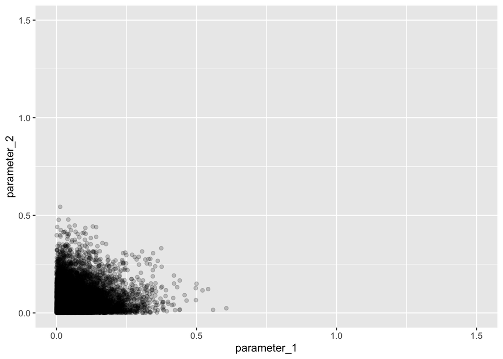

```r
plot_prior_samples <- function(shape1_parameter_1 = 1,
                               shape2_parameter_1 = 1,
                               shape1_parameter_2 = 1,
                               shape2_parameter_2 = 1) {
  parameter_1 <- rbeta(
    n =10000, # how many samples
    shape1 = shape1_parameter_1,
    shape2 = shape2_parameter_1
  ) * 1.5
  parameter_2 <- rbeta(
    n =10000, # how many samples
    shape1 = shape1_parameter_2,
    shape2 = shape2_parameter_2
  ) * 1.5
  tibble(
    parameter_1,
    parameter_2
  ) %>%
    ggplot(aes(x = parameter_1, y = parameter_2)) +
    geom_point(alpha = 0.2) + xlim(0,1.5) + ylim(0,1.5)
}
# that's the flat/uniform priors as used in the lecture
plot_prior_samples(1,20,1,20)
```

```r
marg_lh_exponential <-
  map_dbl(
    1:n_samples,
    function(i) {
      # sample parameter values from the prior distribution
      # - any value between 0 and 1.5 is equally likely
      a <- rbeta(n = 1, shape1 = 1, shape2 = 20) * 1.5
      b <- rbeta(n = 1, shape1 = 1, shape2 = 20) * 1.5
      return(lhExp(a,b))
    }
  ) %>%
  mean()

# marginal likelihood of power model
marg_lh_power <-
  map_dbl(
    1:n_samples,
    function(i) {
      # sample parameter values from the prior distribution
      # - any value between 0 and 1.5 is equally likely
      c <- rbeta(n = 1, shape1 = 1, shape2 = 1) * 1.5
      d <- rbeta(n = 1, shape1 = 1, shape2 = 1) * 1.5
      return(lhPow(c,d))
    }
  ) %>%
  mean()

message(
  "BF in favor of power model: ",
  signif(sum(marg_lh_power) / sum(marg_lh_exponential),6)
)
```

```
## BF in favor of power model: 2.01697e+16
```

By choosing $\beta = 20$ for our priors of the exponential model we move the prior distribution of parameters to the left (parameter a) and down (parameter b), which makes the probability of our maximum likelihood estimate very low thus lowering the posterior probability of the whole model. Therefore bayes factor overwhelmingly favors the power model over the exponential model.

# Exercise 2: Testing hypotheses about coins (32 points)

### Frequentist p-value (8 points)

```r
binom.test(x = 21, n = 30, p = 0.5, alternative = "two.sided")
```

```
##
##  Exact binomial test
##
## data:  21 and 30
## number of successes = 21, number of trials = 30, p-value = 0.04277
## alternative hypothesis: true probability of success is not equal to 0.5
## 95 percent confidence interval:
##  0.5060410 0.8526548
## sample estimates:
## probability of success
##                    0.7
```

Using the binomial test we got a significant test result (N=30, k=21, p-value = 0.042), which means we found evidence against the null hypothesis. Therefore, we reject $H_0: \theta=0.5$ and accept the alternative hypothesis of the coin not being fair.

### Bayesian estimation-based testing for a point-valued hypothesis (8 points)

```r
interval <- tibble(
  # shape1 = alpha = heads+1 = 22, shape2 = beta = tails+1 = 10
  `lower_Bayes` = HDInterval::hdi(function(x) qbeta(x, 22,10))[1],
  `upper_Bayes` = HDInterval::hdi(function(x) qbeta(x, 22,10))[2],
) %>%
  pivot_longer(
    everything(),
    names_pattern = "(.*)_(.*)",
    names_to = c(".value", "approach")
  )
interval
```

```
## # A tibble: 1 x 3
##   approach lower upper
##   <chr>    <dbl> <dbl>
## 1 Bayes    0.528 0.840
```

The point-value $\theta=0.5$ is out of bounds which means we might reject our hypothesis of the coin being fair.

### Bayesian estimation-based testing for ROPE-d hypothesis (8 points)

```r
interval <- tibble(
  # ROPE-d interval is our point-valued HDI + epsilon (0.01)
  `lower_Bayes` = HDInterval::hdi(function(x) qbeta(x, 22,10))[1] + 0.01,
  `upper_Bayes` = HDInterval::hdi(function(x) qbeta(x, 22,10))[2] + 0.01,
) %>%
  pivot_longer(
    everything(),
    names_pattern = "(.*)_(.*)",
    names_to = c(".value", "approach")
  )
interval
```

```
## # A tibble: 1 x 3
##   approach lower upper
##   <chr>    <dbl> <dbl>
## 1 Bayes    0.538 0.850
```

Even after using the ROPE-d approach, $\theta = 0.5$ is excluded from our confidence interval, which is why we again reject the null hypothesis of the coin being fair.

### Savage Dickey model comparison for point-valued hypothesis (8 points)

```r
# point-value of nested model M0
theta_star <- 0.5
# posterior probability in nesting model
posterior_theta_star <- dbeta(theta_star, 22, 10)
# prior probability in nesting model
prior_theta_star <- dbeta(theta_star, 1, 1)
# Bayes factor (using Savage Dickey)
BF01 <- posterior_theta_star / prior_theta_star
BF01
```

```
## [1] 0.4130617
```

As our bayes factor of the alternative model is very low ($BF_{10} \approx 2.421$) we might not conclude any (strong) evidence against the null hypothesis which is why we cannot say significantly whether the coin is fair or not.